# Computational Musicology Portfolio

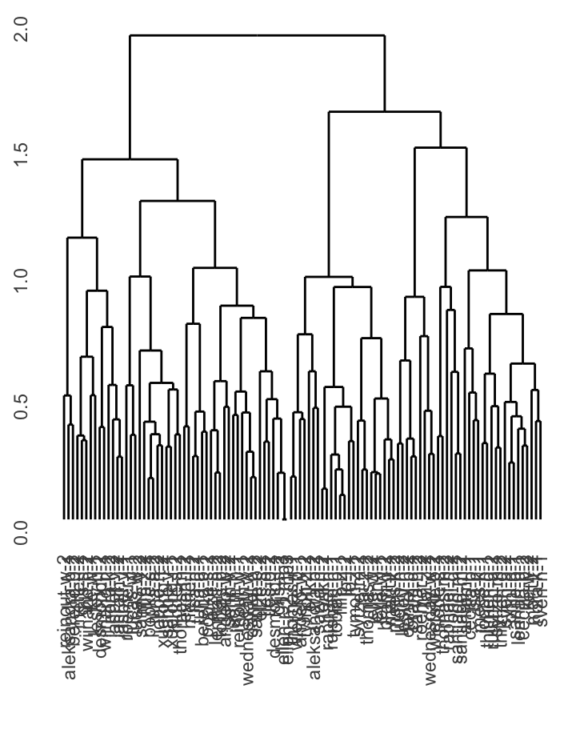

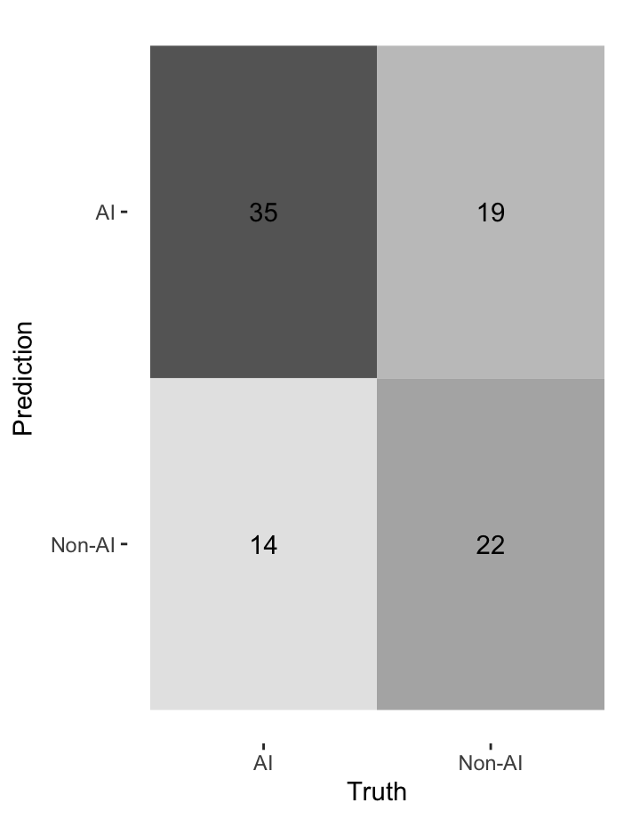

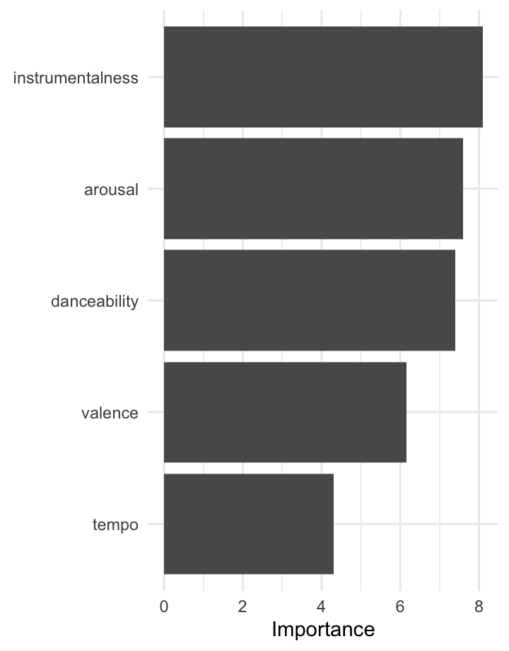

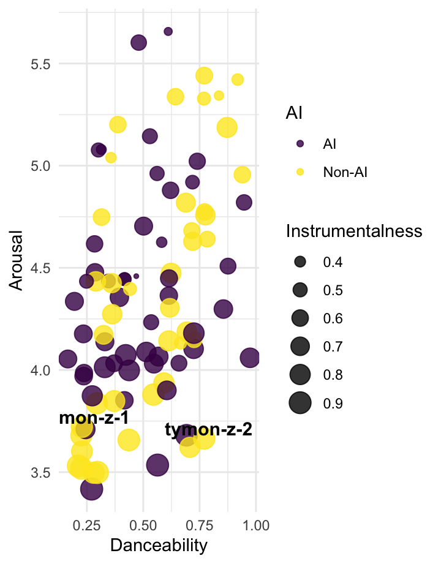

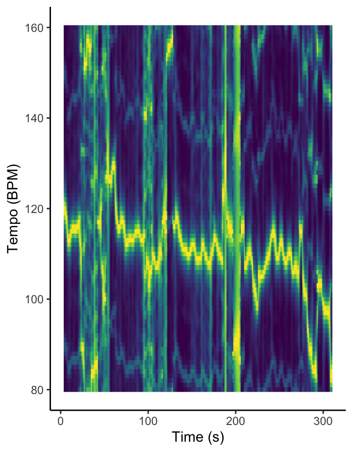

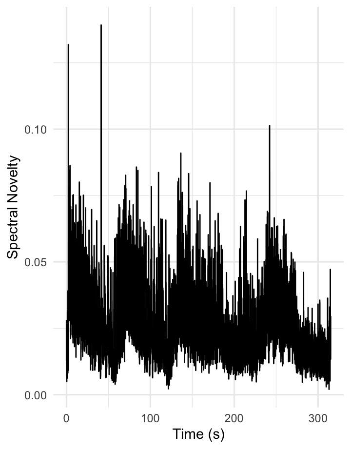

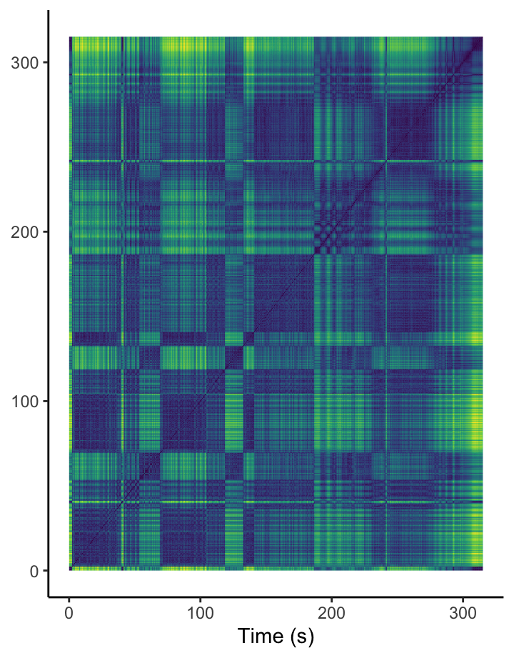

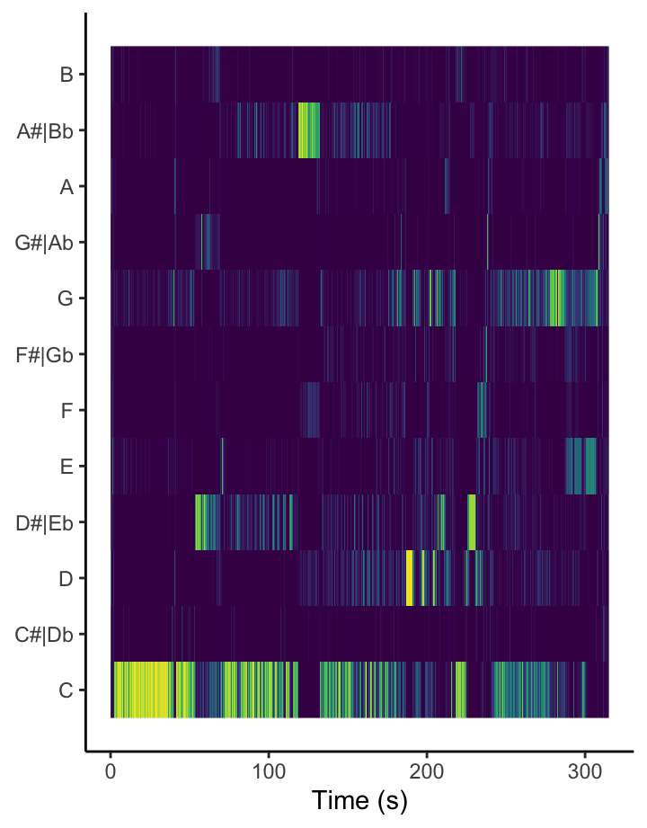

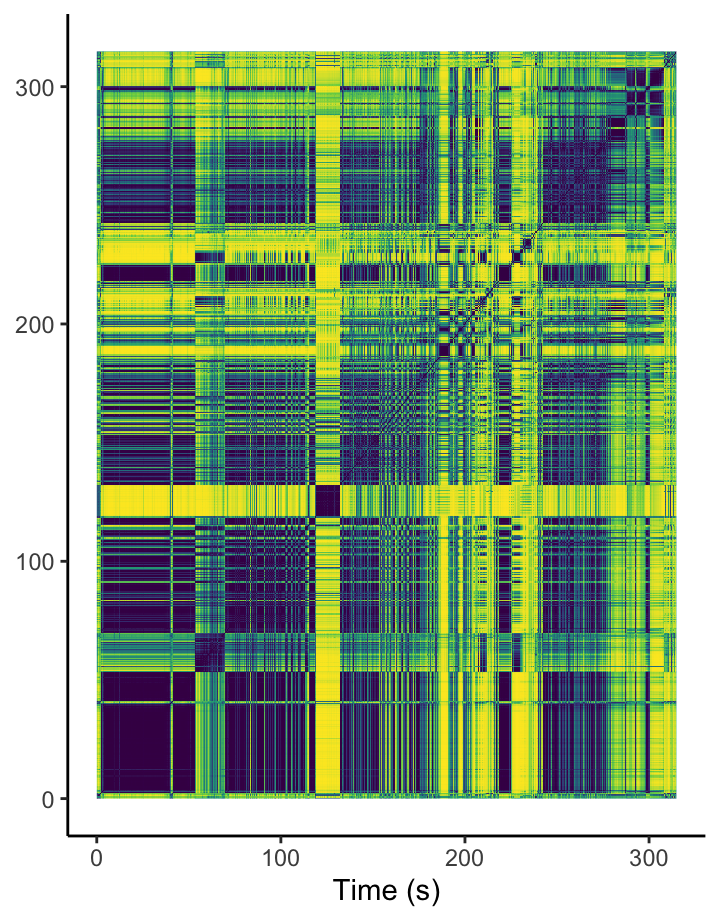

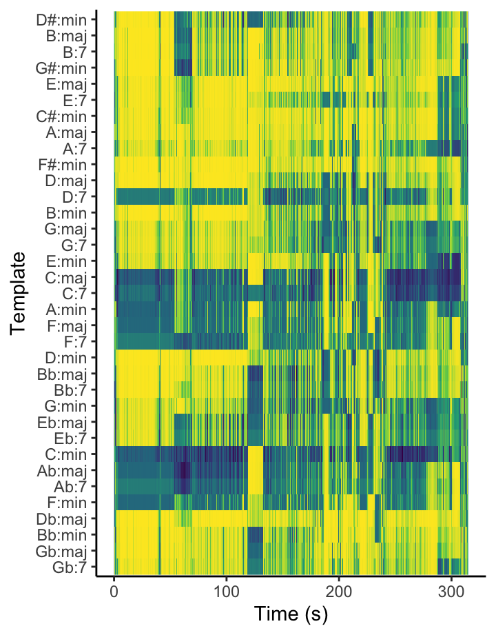

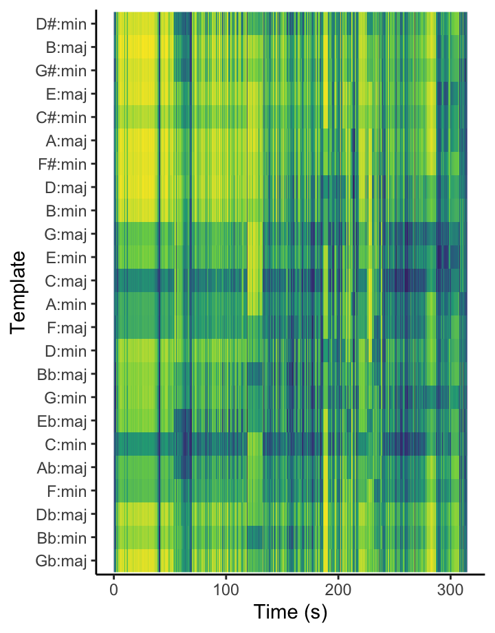

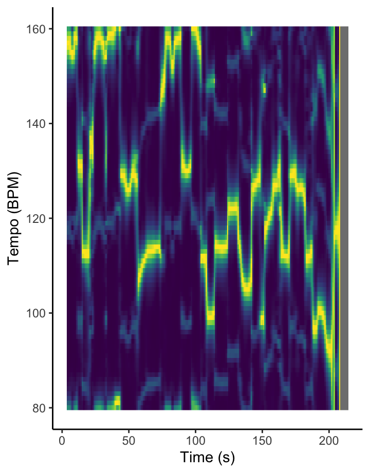

[6 more figures not shown]

### Introduction

Welcome to my portfolio! Here I will explore the two tracks I have submitted as part of the class corpus and features that relate to them. Both pieces submitted are composed by me.

The first piece is called ‘Conjunction no. 3’ for violin, viola, cello and contrabass clarinet - so purely acoustic forces. ‘Conjunctions’ is a series where I explore simple rhythmical structures that change over time. This third ‘Conjunction’ has a clear form which is shown on the self-similarity matrices pretty well.  
The second file is quite a different one. It is an exercise for a class I have at Conservatorium called ‘musical texture’. This one is an electronic piece, consisting of 4 voices on the same e-instrument of various pulsations. The 4 voices move through a harmony from my choral piece years ago and create a ‘soundmass’. Therefore, many of the pitch- and timbre-related visualisations tend to not be effective.

First, let’s see some general trends and relationship of my pieces to the class corpus. Then, I will offer some insight into both pieces using a variety of visualisatios which showcase (surprisingly large) differences between the pieces.

### Clustering and Dendrogram

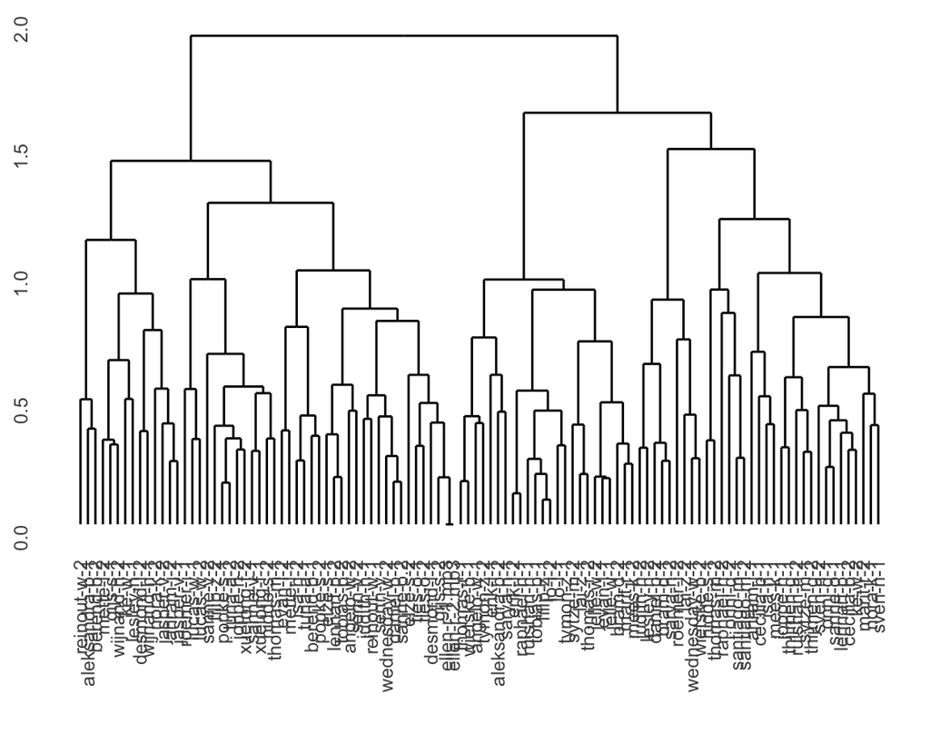

First, let’s see what sort of results unsupervised learning will yield when applied to the class corpus to generate a dendrogram (hierarchical clustering). Distance method is Euclidean and method - complete. I am using all the high-level features provided. My pieces sit on branches not too far away from each other. I listened to other pieces in the neighboring branches and I found that Io-l-1 which is a saxophone quartet which is next to my tymon-z-1 makes sense. Both are acoustic pieces belonging to contemporary classical genre. It’s interesting that this similarity was already detectable, maybe thanks to using all the available high-level features! The other piece seemed to be a bit more confusing and neighboring branches do not offer the same type of genre/mood similarity.

### AI? - KNN

```
# A tibble: 2 × 3
  class  precision recall
  <fct>      <dbl>  <dbl>
1 AI         0.648  0.714
2 Non-AI     0.611  0.537
```

#### Plotting Prediction vs Truth

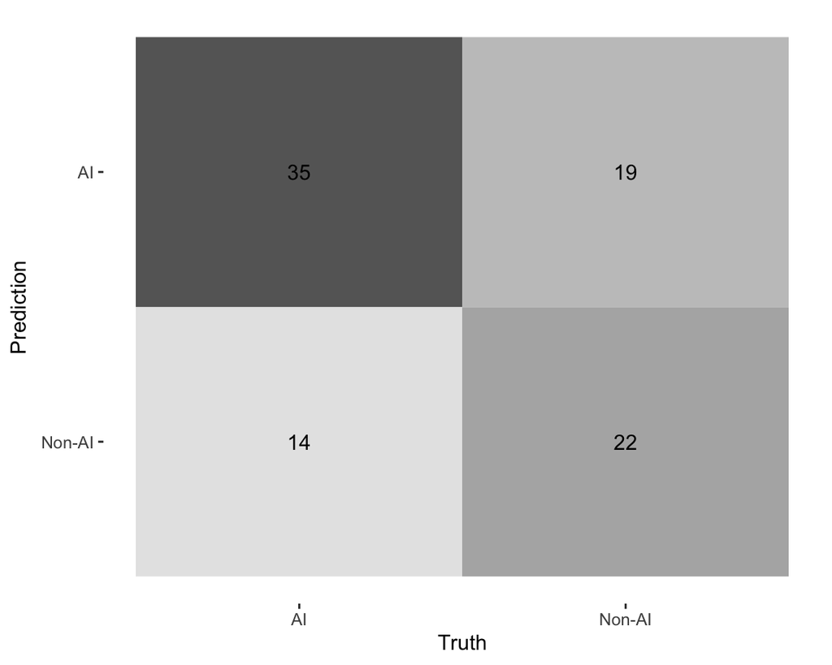

### Most important features - Random Forest

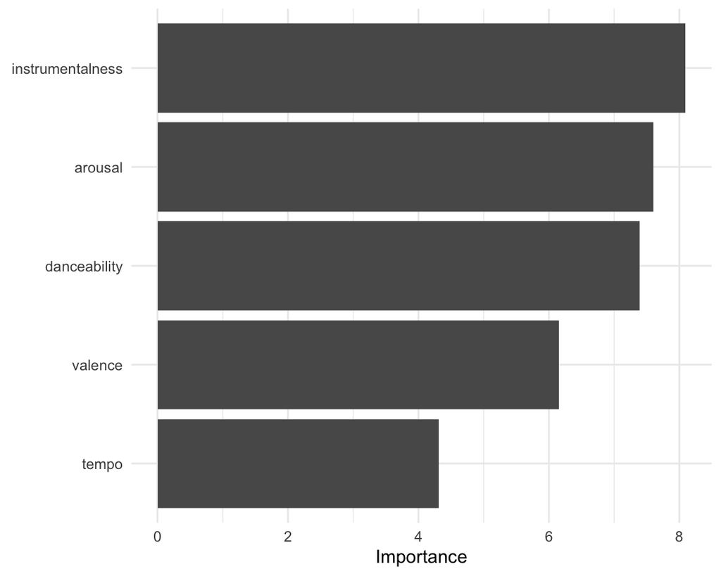

Now I applied a random forest to see which features are most important to distinguish between the pieces. Clearly, instrumentalness and arousal are in the leads with danceability being the third feature. Next slide offers a plot of the class corpus using those features.

### Plotting important features

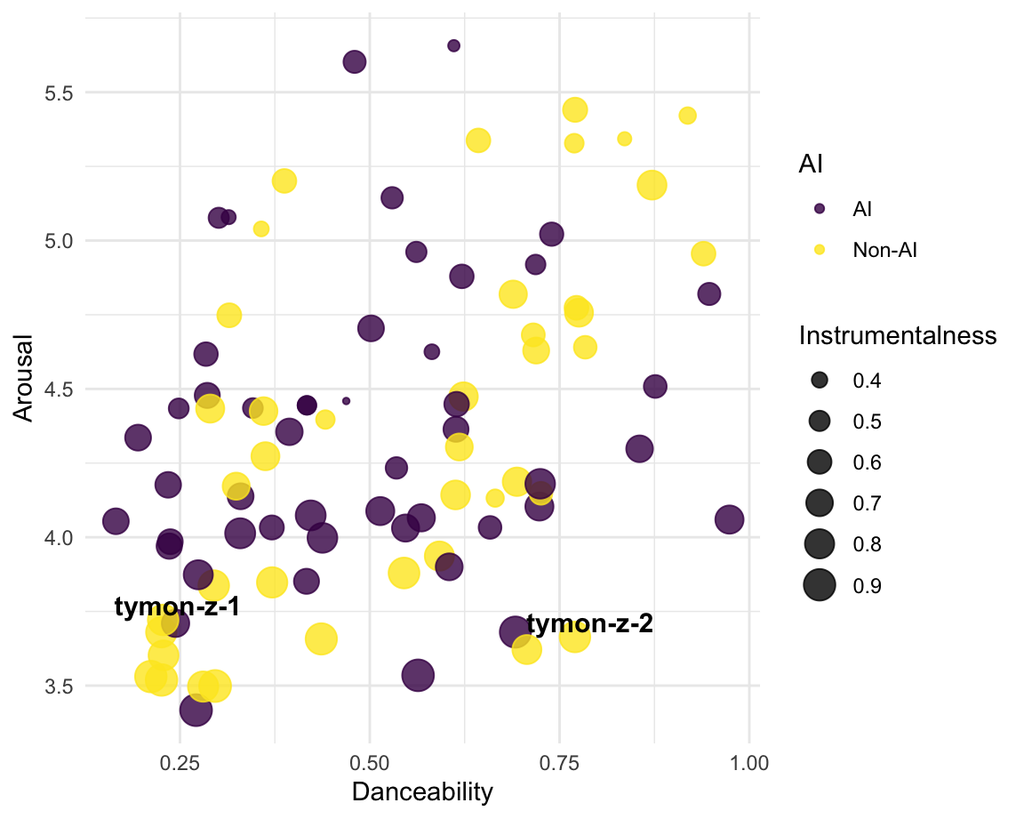

This is the plot of features mentioned on the previous slide. I have added text to show where my pieces are on this plot. For some reason my second piece, which is purely electronic and has no stable beat, seems very danceable. Both pieces seem to be of low arousal and high instrumentalness. Also, of course both are not AI-generated.

It is interesting that tempo is not of importance - I wonder if this is because of how often this feature was not accurate and correlated to other features (such as an upbeat, fast song having a low tempo feature)?

I will now dive into analysing my own pieces.

### Tempogram 1

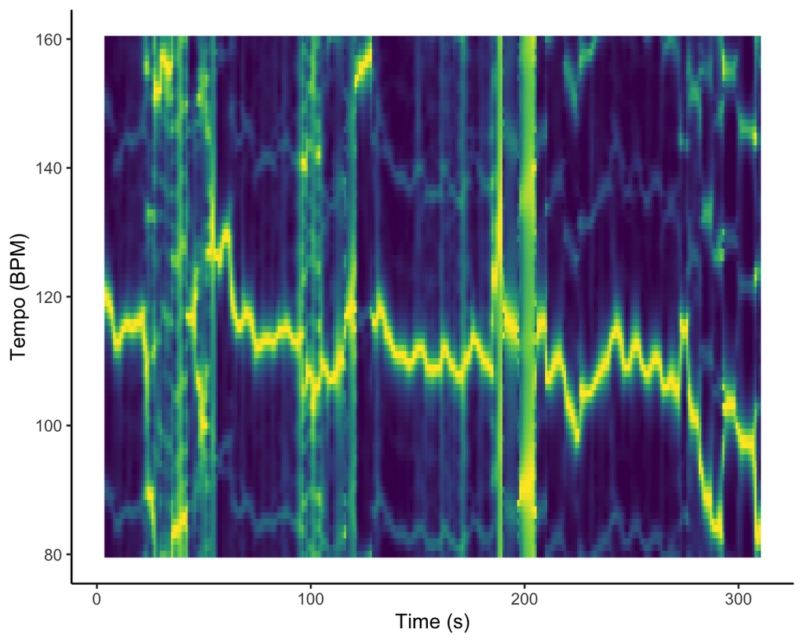

Let’s start with tempo!

The tempogram doesn’t reflect the score which specifies a tempo of stable quarter=60 BPM, although given cyclic=TRUE, it gets the temporal octave of 120 pretty well. In the piece there is constant diminution (decreasing the rhythmical values of the notes). It probably confuses the algorithm into thinking the tempo is different. It is interesting though it does seem relatively good at having a stable (if somewhat slowing down) 120 BPM. If this is accurate, it would suggest that musicians did slow down despite this not being and instruction in the score!

### Spectral Novelty Function 1

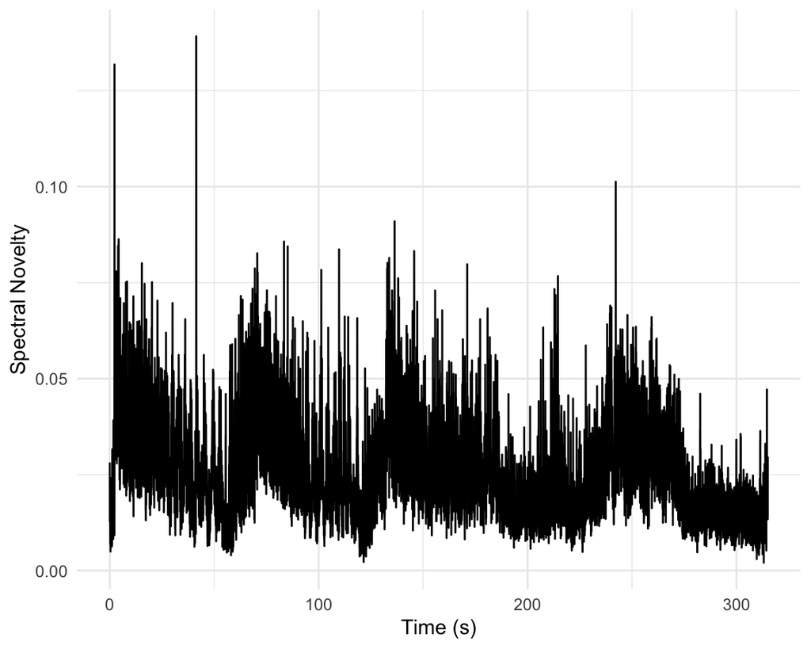

This is a pretty good reflection of the form of the piece, I find it similar in result to the timbre self similarity matrix (next slide), where also 4 main shapes are visible each time a new ‘phase’ of the form starts. Overall this is a helpful guide of when something of importance in the piece happens.

### Timbre Self-similarity Matrix 1

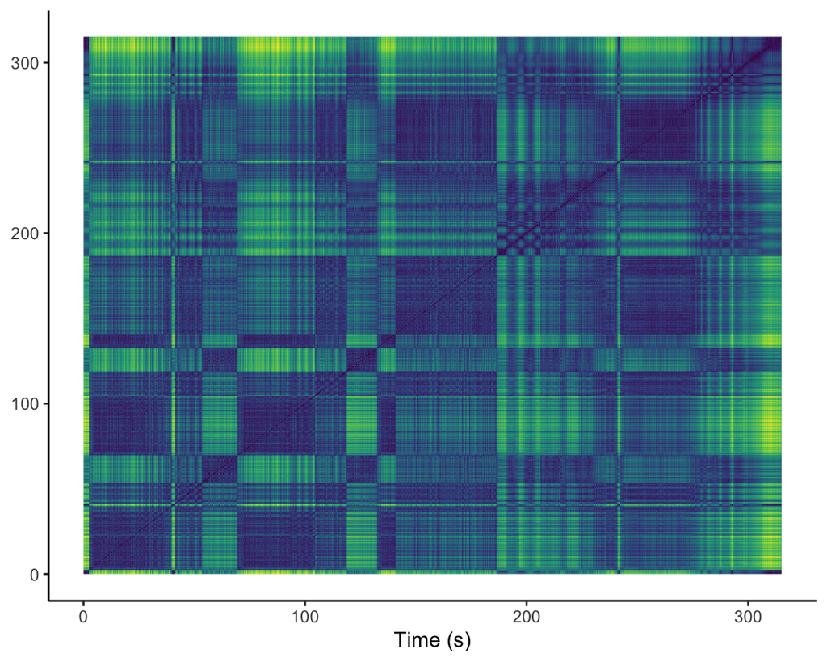

Further visualising the form of the piece is this timbre based self-similarity matrix. Here, it is clear that what we saw on the spectral novelty function holds in terms of making an assessment on the musical structure of my piece: four parts, each starting in a similar way but then changing.

(norm, distance = manhattan)

### Chromagram of piece 1

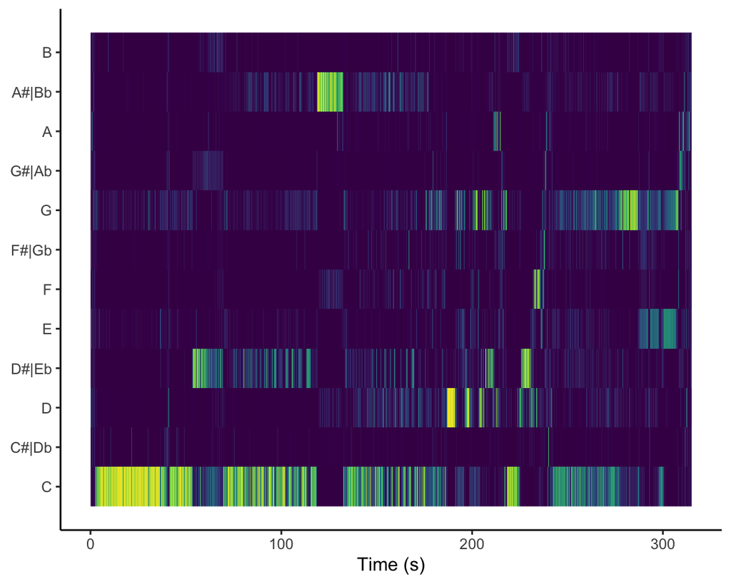

Now let’s go into pitch, chords and keys!

The piece is very simple in terms of pitch material - the first segment has only C as a pitch, the second is an Ab on contrabass clarinet (on the visualisation Eb is coloured, potentially becuase of the nature of clarinet harmonics). We come back to C but an Eb appears - now as it should have. Then bass clarinet plays Bb in a similar segment to earlier. After that the graph becomes more ambiguous because the pitches include C, D, Eb and often as a result of increased bow pressure they detune. The next section is a dialogue between cello and bass clarinet on a few pitches with high minor second in violin+viola.

The stability is reinstated in around 250s in the last part of the piece where C and G return most prominently, most likely again with plenty of string resonance which amplifies these pitches. I am surprised to see E-natural towards the end of the piece, but again I expect this to be harmonics of the low C string of the cello. C is the only pitch at the end of the piece, but maybe the volume and harmonics distort the perception of the algorithm.

(norm = manhattan)

### Chroma Self-similarity Matrix 1

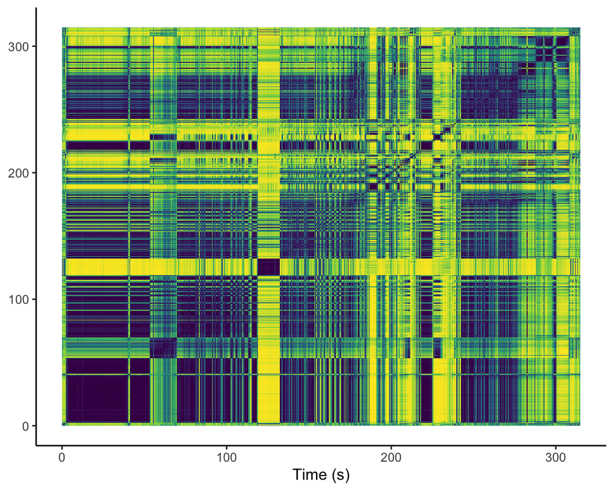

Interesting to see the relationship of the simple form also in terms of pitch on the visualisation! It’s very much possible for me to see which bits in the score are where. I found this one of the more interesting visualisations given it’s accuracy and meaningfulness even in non-computational contexts, such as teaching musical forms in music schools.

(distance = euclidean, distance = cosine)

### Chordogram 1

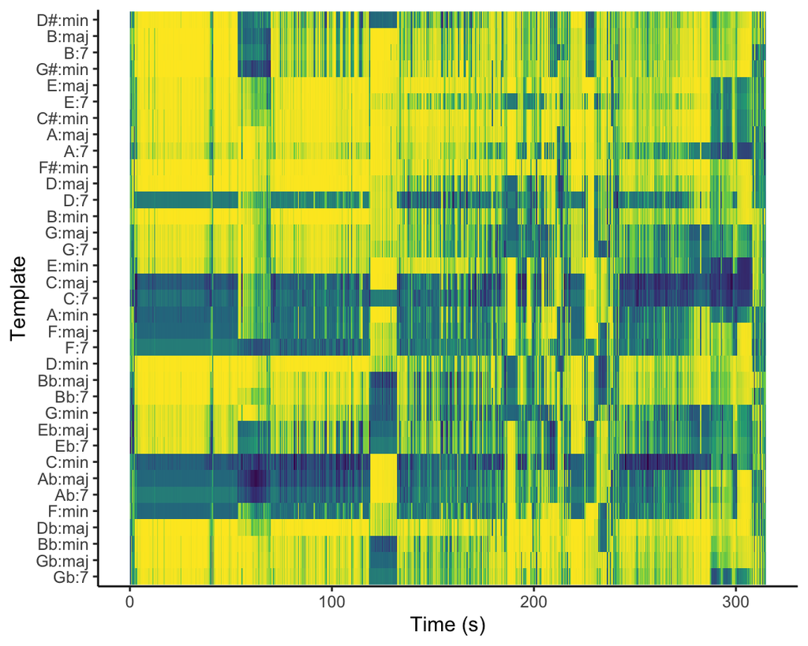

(norm=chebyshev - was helpful in showcasing very strong outliers)

### Keygram 1

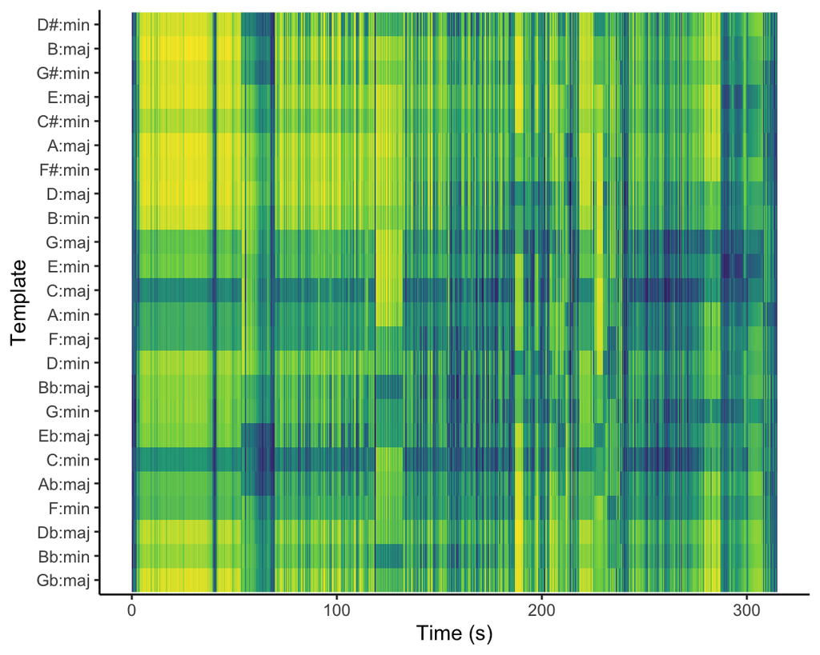

Given the pitch material, the piece is unsurprisingly based on a C scale on this visualisation. Interesting the algorithm detects Eminor towards the end, when the pitches actually are still the same C. As with the chromagraph, maybe it has something to do with harmonics and volume.

(norm = euclidean, distance=cosine)

### Tempogram 2

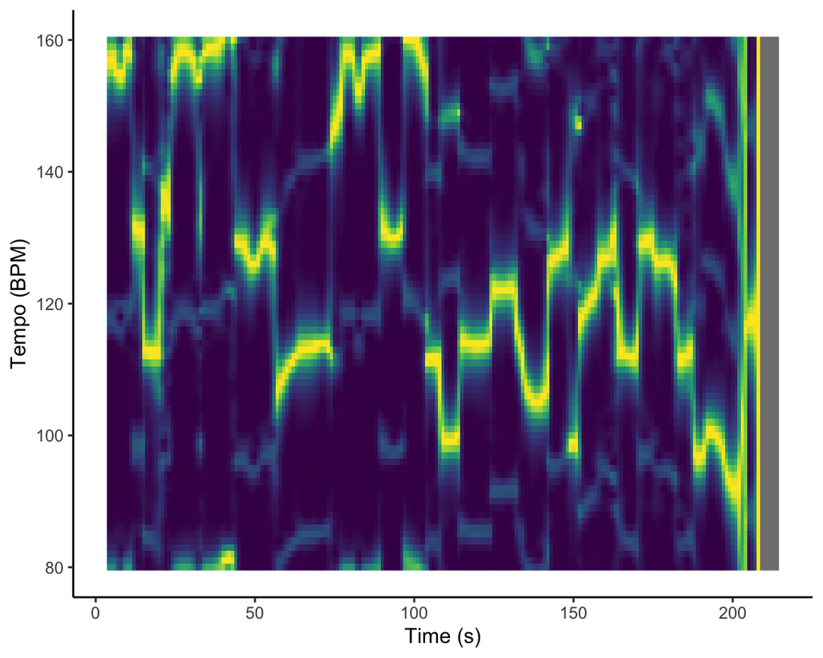

This piece does not have a fixed tempo, instead there are four instruments pulsating at different speeds. Therefore I did not expect any meaningful results, since there is nothing to find. It gives a good attempt though, given the impossibility of the task.

### Spectral Novelty Function 2

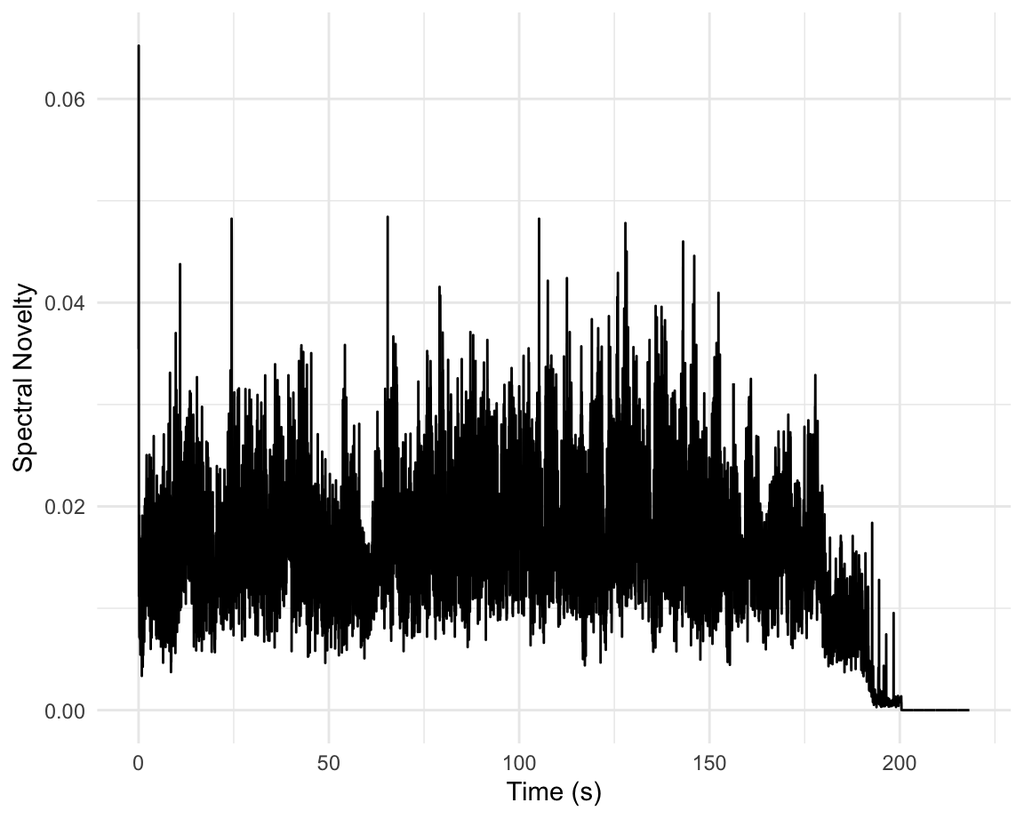

Given the continuous and everchanging nature of this piece I am not surprised the novelty function is not very revealing. The timbre is pretty consistent in the piece.

### Timbre Self-similarity Matrix 2

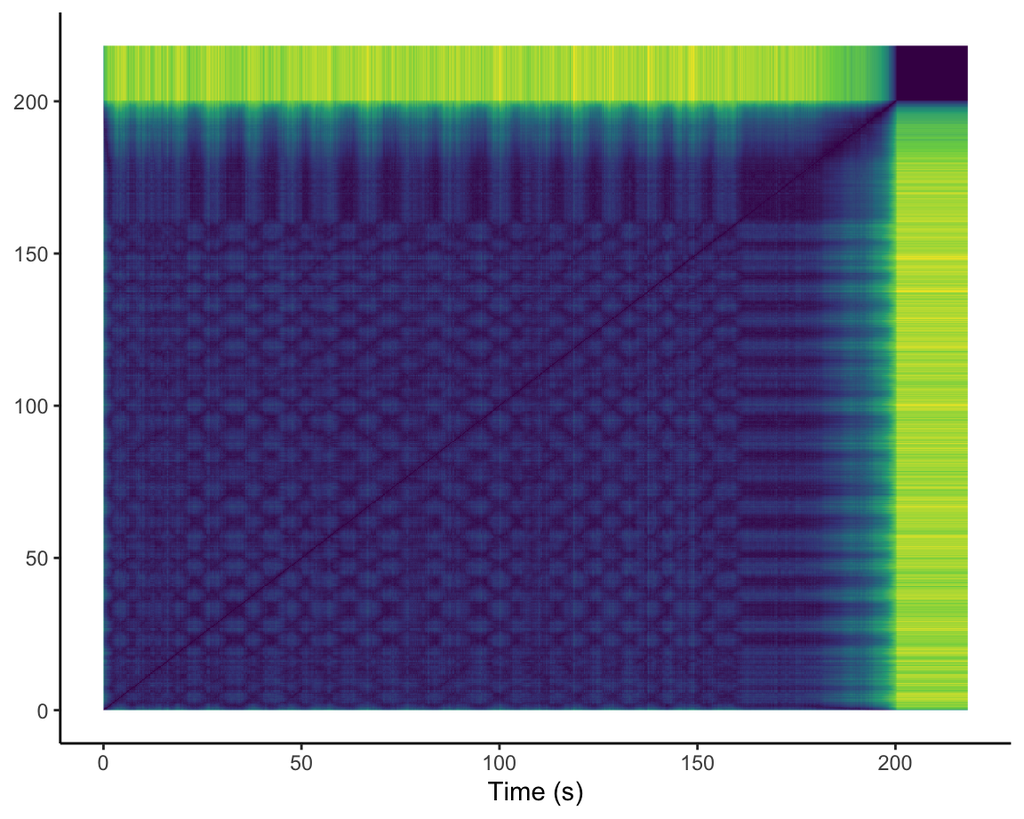

As with spectral novelty, this visualisation underlines the continuous and constant nature of this piece. The matrix is pleasantly dark. I expect pieces of minimal, repetitive music by composers like Philip Glass or Steve Reich to have similar matrices.

(norm, distance = manhattan)

### Chromagram of piece 2

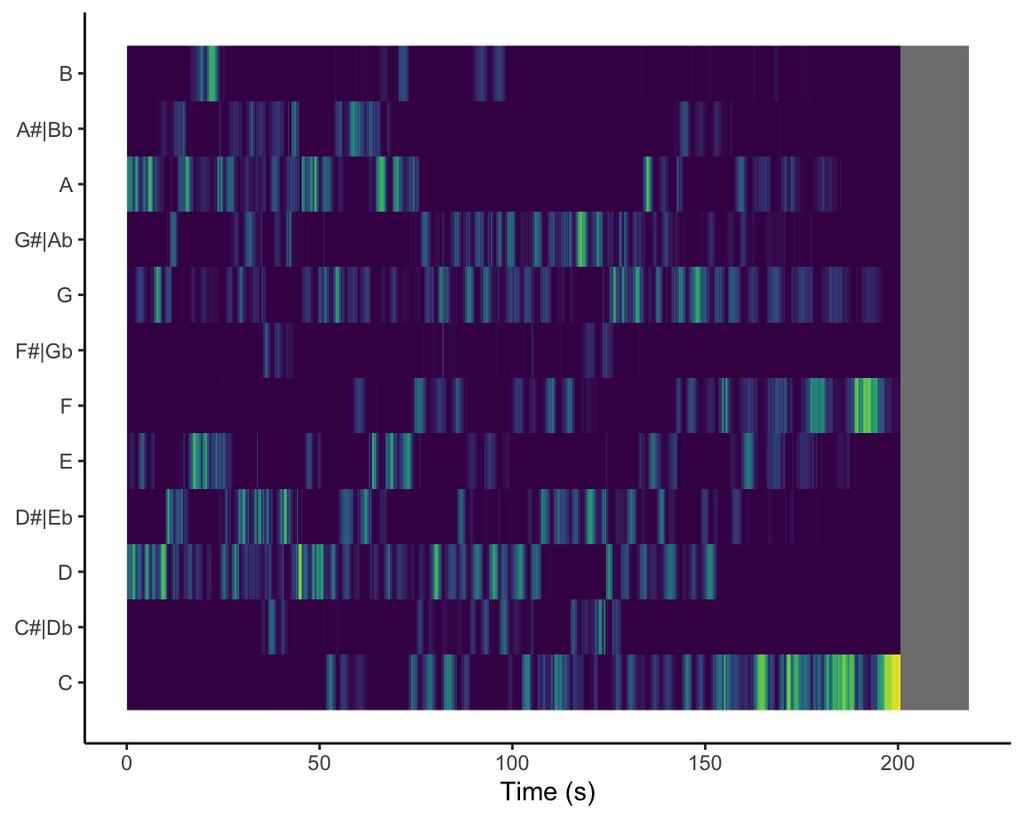

Given there are four instruments, it’s interesting that sometimes there are more than 4 pitches detected. I expect harmonics interfered with the results. In general though, it would be quite possible to map out pitch material in time in this piece. It is also clear that there were many pitches used across the whole piece - the next slides will show if there is a structured way in which they are used.

(norm=manhattan)

### Chroma Self-similarity Matrix 2

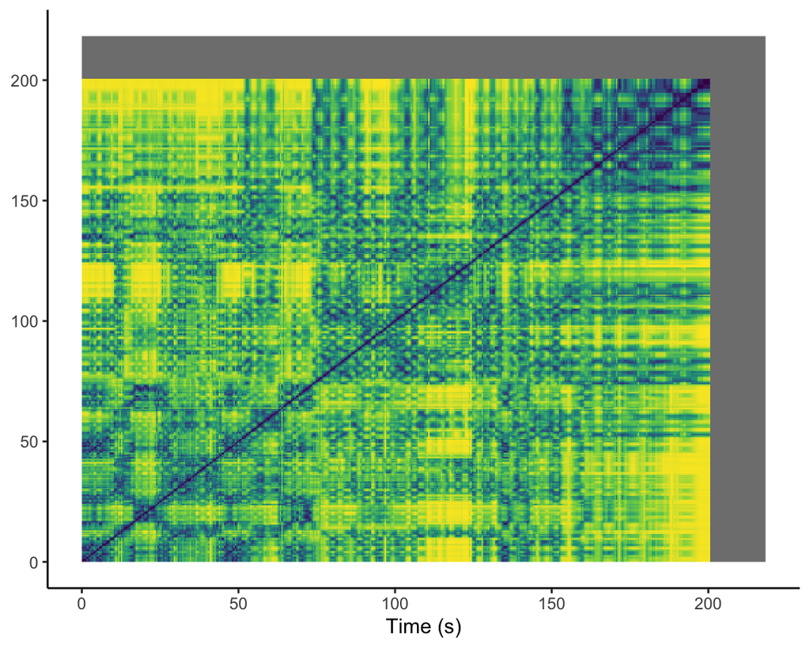

While the chromagram was quite clear in terms of pitches used, this chroma-based similarity matrix shows that the piece continuously changes pitches in a novel way with little to no repetition. I suspect the total amount of pitches used and atonal nature of the piece are the main factors that contribute to this visualisation.

It is fascinating how dissimilar to the timbre similarity matrix of the same piece (two slides before) this matrix is. There is something at play in composition between repetition and novelty and clearly here timbre belongs to one domain (repetition) while pitch to the other (novelty).

(norm, distance = manhattan)

### Chordogram 2

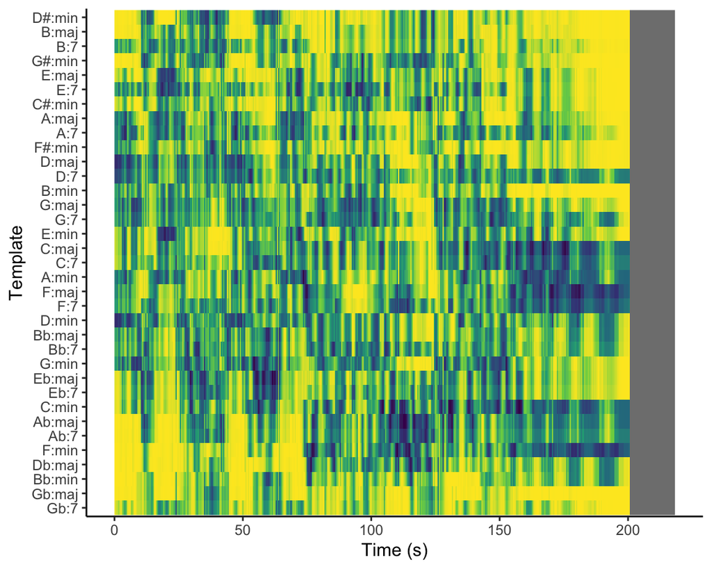

The algorith struggles to find clear, stable chords with so many pitches playing at all the times. Given the atonal nature of the harmony employed in the piece, I did not expect this analysis to bear meaningful results.

(norm = euclidean, distance = cosine)

### Keygram 2

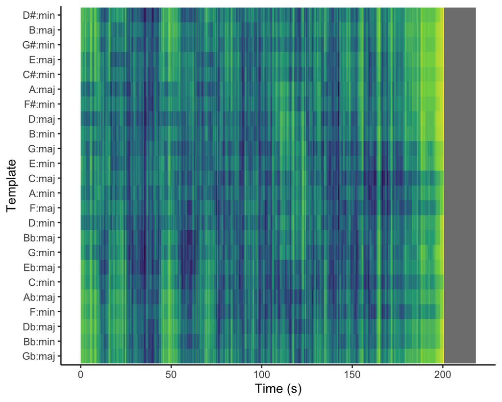

As with the chordogram, I did not expect to find that the piece is in a key given its atonal nature.

(norm, distance = manhattan)

### Conclusions

I hope this short exploration of my both pieces and the class corpus were informative and interesting. I have several concluding remarks:

- Both my pieces are drastically different, starting with electronic vs acoustic separation, but also clearly in all the visualisations for each piece.
- However, in the grand scale of things, as suggested by the dendrogram and clustering, my pieces still are ‘close’ to each other on the canvas of class corpus. Maybe this shows belonging to the ‘contemporary classical’ genre or indicates that despite being so different, there are some hidden similarities caused by being composed by the same artist.
- High level features despite appearing simple numbers seem to contain some hidden truths as they succsessfully allowed to connect both of my pieces on the dendrogram.
- Visualisations are a great tool to analyse music, especially musical form and pitch material. I found key and tempo interpretations less applicable for teaching and less useful in the context of my pieces.

I believe all the techniques I employed in this portfolio to be highly applicable to teaching music, music production and composition. Showing a different way we can represent and analyse music is crucial to developing a new generation of musicians. Music curriculum in conservatoroires is very resistant to change and inclusion of technology - it’s time to change that.